# Predictive Models for NFL Betting Strategies

### Manhattan kNN evaluation

In this section we will define our k range to be from 3 (i.e. # of classes + 1) to 50. Since we have many objects it was felt we could discover more and hopefully increase accuracies and precisions with larger k values. We will use this range for all runs of the kNN evaluator below.

Next we perform our first evaluation using Manhattan similarity. We will perform a run on both the high dimensional data set (115 dimensions) and the low dimensional data set (19 dimensions). As stated earlier, the high dimensional data set retains the characteristics for the home team, away team, and favorite team categorical variables that were converted into dummy variables.

#### kNN Accuracy Evaluation

Comparing the accuracies between the high dimensional and low dimensional data sets we see that there is a small improvement for all accuracies in the low dimensional data set. Here is a summary:

- Spread winner mean accuracy better at 52.0% vs 51.87%
- Spread winner best accuracy better at 53.77% vs 52.99%
- Over/under winner mean accuracy better at 52.07% vs 50.29%
- Over/under best accuracy better at 53.1% vs 51.61%

This is good as it shows the extra dimensions are not needed from the high dimensional data set and could be dropped to increase kNN performance.

Also worth noting is the spread winner and over/under winner accuracies for the low dimension data set are about the same, as can be seen in the corresponding plot below.

#### kNN Spread Winner Precision

In this section we evaluate the precision for both classes of the spread winner label. Since the numbers support using the low dimensional data set analysis will be focused on those results. When we compare the precision (true positive rate) for when predicting whether an underdog will beat the spread or the favorite will beat the spread we found predictions for underdogs were significantly better. Here is a summary:

- Mean precision for underdogs was better than favorites, 54.08% vs 48.91%
- Best precision for underdogs was better than favorites, 56.36% vs 50.98%
- Best/peak precision for both was found at k = 4. This is good as it decreases computation needed for model prediction.

#### kNN Over/Under Winner Precision

In this section we evaluate the precision for both classes of the over/under winner label. Since the numbers support using the low dimensional data set analysis will be focused on those results. When we compare the precision (true positive rate) for when predicting whether a score will beat the over or under the over/under value we found predictions for unders were slightly better. Here is a summary:

- Mean precision for unders was better than overs, 52.71% vs 51.36%
- Best precision for unders was better than overs, 53.78% vs 52.49%
- Best/peak precision for unders was found at k = 12 and for overs was found at k = 49. This could be compuationally expensive, especially for overs.

```
===============================================================================
= kNN evaluation on high dimensional NFL data set
===============================================================================
```

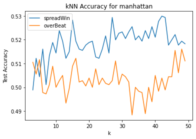

```
spreadWin Accuracy Summary:
	Mean accuracy = 0.5187
	Median accuracy = 0.5194
	Best accuracy = 0.5299, for k = 42
overBeat Accuracy Summary:
	Mean accuracy = 0.5029
	Median accuracy = 0.5028
	Best accuracy = 0.5161, for k = 48
```

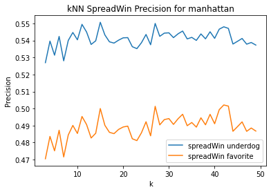

```
Underdog (spreadWin=0) Precision Summary:
	Mean precision = 0.5411
	Median precision = 0.5412
	Best precision = 0.5507, for k = 15
Favorite (spreadWin=1) Precision Summary:
	Mean precision = 0.4892
	Median precision = 0.4897
	Best precision = 0.5021, for k = 42
```

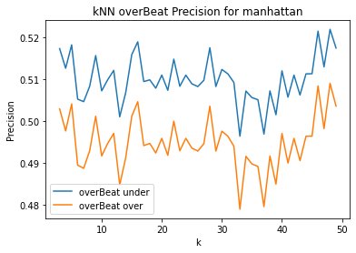

```
Under (overBeat=0) Precision Summary:
	Mean precision = 0.5100
	Median precision = 0.5098
	Best precision = 0.5220, for k = 48
Over (overBeat=1) Precision Summary:
	Mean precision = 0.4948
	Median precision = 0.4946
	Best precision = 0.5091, for k = 48


===============================================================================
= kNN evaluation on low dimensional NFL data set
===============================================================================
```

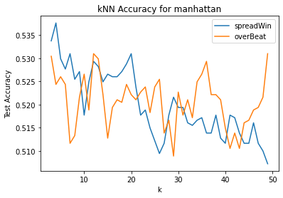

```
spreadWin Accuracy Summary:
	Mean accuracy = 0.5200
	Median accuracy = 0.5177
	Best accuracy = 0.5377, for k = 4
overBeat Accuracy Summary:
	Mean accuracy = 0.5207
	Median accuracy = 0.5210
	Best accuracy = 0.5310, for k = 12
```

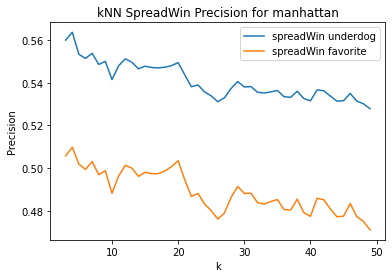

```
Underdog (spreadWin=0) Precision Summary:
	Mean precision = 0.5408
	Median precision = 0.5380
	Best precision = 0.5636, for k = 4
Favorite (spreadWin=1) Precision Summary:
	Mean precision = 0.4891
	Median precision = 0.4868
	Best precision = 0.5098, for k = 4
```

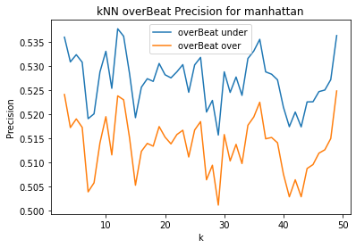

```
Under (overBeat=0) Precision Summary:
	Mean precision = 0.5271
	Median precision = 0.5276
	Best precision = 0.5378, for k = 12
Over (overBeat=1) Precision Summary:
	Mean precision = 0.5136
	Median precision = 0.5141
	Best precision = 0.5249, for k = 49
```

```python
# Select k range with minimum of 3 (# of classes + 1) and go up to 50
k_range = range(3, 50)

print("===============================================================================")
print("= kNN evaluation on high dimensional NFL data set")
print("===============================================================================")
knn_evaluation(dataReducedAlt, targetVars, k_range, similarity_metric='manhattan')

print("===============================================================================")
print("= kNN evaluation on low dimensional NFL data set")
print("===============================================================================")
knn_evaluation(dataReduced, targetVars, k_range, similarity_metric='manhattan')
```

### Euclidean kNN evaluation

Next we perform our second evaluation using Euclidean similarity. We will perform a run on both the high dimensional data set and the low dimensional data set again too.

#### kNN Accuracy Evaluation

Comparing the accuracies between the high dimensional and low dimensional data sets we see that there is a small improvement for all accuracies in the low dimensional data set. Here is a summary:

- Spread winner mean accuracy better at 52.51% vs 51.39%
- Spread winner best accuracy better at 53.71% vs 52.60%
- Over/under winner mean accuracy better at 52.99% vs 51.29%
- Over/under best accuracy better at 54.54% vs 53.05%

This again is good as it shows the extra dimensions are not needed from the high dimensional data set and could be dropped to increase kNN performance.

Also worth noting is the over/under winner accuracies tend to get better when compared against spread winner accuracies for the low dimension data set as k increases, as can be seen in the corresponding plot below.

#### kNN Spread Winner Precision

In this section we evaluate the precision for both classes of the spread winner label. Since the numbers support using the low dimensional data set analysis will be focused on those results. When we compare the precision (true positive rate) for when predicting whether an underdog will beat the spread or the favorite will beat the spread we found predictions for underdogs were significantly better again. Here is a summary:

- Mean precision for underdogs was better than favorites, 54.46% vs 49.60%
- Best precision for underdogs was better than favorites, 56.02% vs 51.11%
- Best/peak precision for both was found at k = 4 for underdogs and k = 21 for favorites. These are low to moderate and don't substantially increase computation needed for model prediction.

#### kNN Over/Under Winner Precision

In this section we evaluate the precision for both classes of the over/under winner label. Since the numbers support using the low dimensional data set analysis will be focused on those results. When we compare the precision (true positive rate) for when predicting whether a score will beat the over or under the over/under value we found predictions for unders were slightly better again. Here is a summary:

- Mean precision for unders was better than overs, 53.63% vs 52.31%
- Best precision for unders was better than overs, 55.16% vs 53.8%
- Best/peak precision for both were found at k = 39. This could be more compuationally expensive.

```
===============================================================================
= kNN evaluation on high dimensional NFL data set
===============================================================================
```

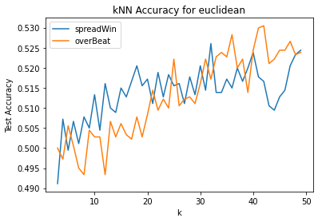

```
spreadWin Accuracy Summary:
	Mean accuracy = 0.5139
	Median accuracy = 0.5150
	Best accuracy = 0.5260, for k = 32
overBeat Accuracy Summary:
	Mean accuracy = 0.5129
	Median accuracy = 0.5122
	Best accuracy = 0.5305, for k = 42
```

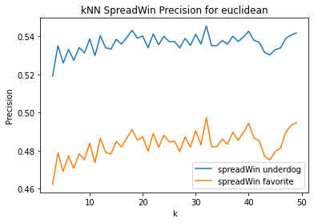

```
Underdog (spreadWin=0) Precision Summary:
	Mean precision = 0.5362
	Median precision = 0.5368
	Best precision = 0.5455, for k = 32
Favorite (spreadWin=1) Precision Summary:
	Mean precision = 0.4832
	Median precision = 0.4838
	Best precision = 0.4973, for k = 32
```

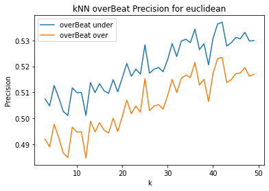

```
Under (overBeat=0) Precision Summary:
	Mean precision = 0.5198
	Median precision = 0.5189
	Best precision = 0.5371, for k = 42
Over (overBeat=1) Precision Summary:
	Mean precision = 0.5054
	Median precision = 0.5047
	Best precision = 0.5234, for k = 42


===============================================================================
= kNN evaluation on low dimensional NFL data set
===============================================================================
```

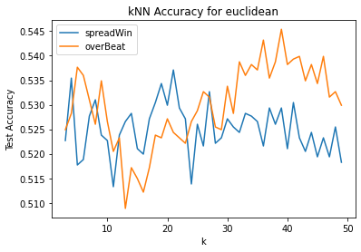

```
spreadWin Accuracy Summary:
	Mean accuracy = 0.5251
	Median accuracy = 0.5255
	Best accuracy = 0.5371, for k = 21
overBeat Accuracy Summary:
	Mean accuracy = 0.5299
	Median accuracy = 0.5310
	Best accuracy = 0.5454, for k = 39
```

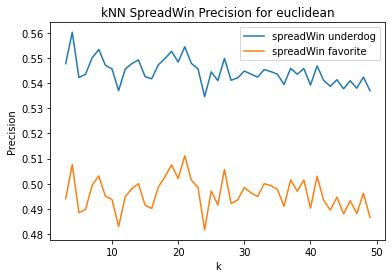

```
Underdog (spreadWin=0) Precision Summary:
	Mean precision = 0.5446
	Median precision = 0.5445
	Best precision = 0.5602, for k = 4
Favorite (spreadWin=1) Precision Summary:
	Mean precision = 0.4960
	Median precision = 0.4962
	Best precision = 0.5111, for k = 21
```

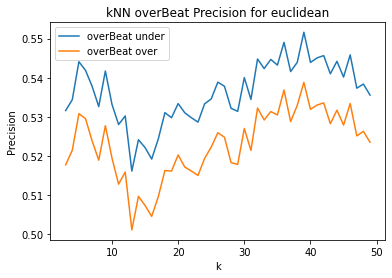

```
Under (overBeat=0) Precision Summary:
	Mean precision = 0.5363
	Median precision = 0.5373
	Best precision = 0.5516, for k = 39
Over (overBeat=1) Precision Summary:
	Mean precision = 0.5231
	Median precision = 0.5239
	Best precision = 0.5388, for k = 39
```

```python
print("===============================================================================")
print("= kNN evaluation on high dimensional NFL data set")
print("===============================================================================")
knn_evaluation(dataReducedAlt, targetVars, k_range, similarity_metric='euclidean')

print("===============================================================================")
print("= kNN evaluation on low dimensional NFL data set")
print("===============================================================================")
knn_evaluation(dataReduced, targetVars, k_range, similarity_metric='euclidean')
```

### Chebyshev kNN evaluation

Next we perform our third evaluation using Chebyshev similarity. This was chosen to add more diversity and exploratory. We will perform a run on both the high dimensional data set and the low dimensional data set again.

#### kNN Accuracy Evaluation

Comparing the accuracies between the high dimensional and low dimensional data sets we see that there is a some improvement for all accuracies in the low dimensional data set. Here is a summary:

- Spread winner mean accuracy better at 52.81% vs 50.32%
- Spread winner best accuracy better at 54.37% vs 51.83%
- Over/under winner mean accuracy better at 53.91% vs 50.98%
- Over/under best accuracy better at 55.54% vs 52.66%

This again is good as it shows the extra dimensions are not needed from the high dimensional data set and could be dropped to increase kNN performance.

Also worth noting is the over/under winner accuracies tend to get better when compared against spread winner accuracies for the low dimension data set as k increases, as can be seen in the corresponding plot below.

#### kNN Spread Winner Precision

In this section we evaluate the precision for both classes of the spread winner label. Since the numbers support using the low dimensional data set analysis will be focused on those results. When we compare the precision (true positive rate) for when predicting whether an underdog will beat the spread or the favorite will beat the spread we found predictions for underdogs were significantly better again. Here is a summary:

- Mean precision for underdogs was better than favorites, 54.7% vs 50.0%
- Best precision for underdogs was better than favorites, 56.13% vs 51.88%
- Best/peak precision for both was found at k = 18 for both. These are moderate and create moderately more computation needed for model prediction.

#### kNN Over/Under Winner Precision

In this section we evaluate the precision for both classes of the over/under winner label. Since the numbers support using the low dimensional data set analysis will be focused on those results. When we compare the precision (true positive rate) for when predicting whether a score will beat the over or under the over/under value we found predictions for unders were slightly better again. Here is a summary:

- Mean precision for unders was better than overs, 54.46% vs 53.30%
- Best precision for unders was better than overs, 55.95% vs 55.07%
- Best/peak precision for both were found at k = 40. This could be more compuationally expensive.

```
===============================================================================
= kNN evaluation on high dimensional NFL data set
===============================================================================
```

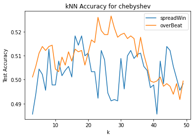

```
spreadWin Accuracy Summary:
	Mean accuracy = 0.5032
	Median accuracy = 0.5039
	Best accuracy = 0.5183, for k = 16
overBeat Accuracy Summary:
	Mean accuracy = 0.5098
	Median accuracy = 0.5111
	Best accuracy = 0.5266, for k = 27
```

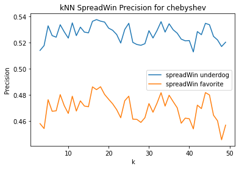

```
Underdog (spreadWin=0) Precision Summary:
	Mean precision = 0.5269
	Median precision = 0.5275
	Best precision = 0.5376, for k = 17
Favorite (spreadWin=1) Precision Summary:
	Mean precision = 0.4698
	Median precision = 0.4709
	Best precision = 0.4862, for k = 18
```

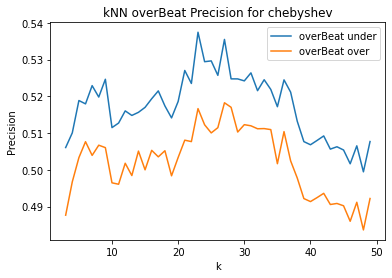

```
Under (overBeat=0) Precision Summary:
	Mean precision = 0.5173
	Median precision = 0.5179
	Best precision = 0.5374, for k = 23
Over (overBeat=1) Precision Summary:
	Mean precision = 0.5022
	Median precision = 0.5034
	Best precision = 0.5182, for k = 27


===============================================================================
= kNN evaluation on low dimensional NFL data set
===============================================================================
```

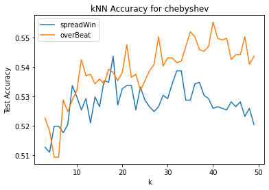

```
spreadWin Accuracy Summary:
	Mean accuracy = 0.5281
	Median accuracy = 0.5282
	Best accuracy = 0.5437, for k = 18
overBeat Accuracy Summary:
	Mean accuracy = 0.5391
	Median accuracy = 0.5410
	Best accuracy = 0.5554, for k = 40
```

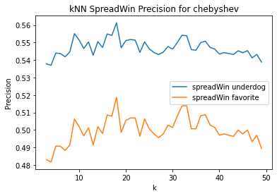

```
Underdog (spreadWin=0) Precision Summary:
	Mean precision = 0.5470
	Median precision = 0.5463
	Best precision = 0.5613, for k = 18
Favorite (spreadWin=1) Precision Summary:
	Mean precision = 0.5000
	Median precision = 0.5000
	Best precision = 0.5188, for k = 18
```

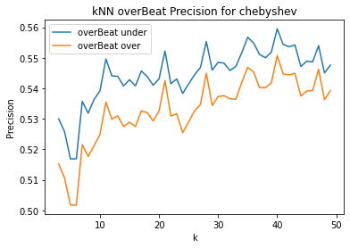

```
Under (overBeat=0) Precision Summary:
	Mean precision = 0.5446
	Median precision = 0.5458
	Best precision = 0.5595, for k = 40
Over (overBeat=1) Precision Summary:
	Mean precision = 0.5330
	Median precision = 0.5346
	Best precision = 0.5507, for k = 40
```

```python
print("===============================================================================")
print("= kNN evaluation on high dimensional NFL data set")
print("===============================================================================")
knn_evaluation(dataReducedAlt, targetVars, k_range, similarity_metric='chebyshev')

print("===============================================================================")
print("= kNN evaluation on low dimensional NFL data set")
print("===============================================================================")
knn_evaluation(dataReduced, targetVars, k_range, similarity_metric='chebyshev')
```

### kNN Evaluation Summary

In the code below we take the four best models as discovered above and run an ROC plot on them. The four best models are the best models in each of the following categories:

- Best spreadWin Accuracy
- Best overBeat Accuracy
- Best spreadWin Precision
- Best overBeat Precision

In one case, for the "Best spreadWin Precision" model, there was a virtual tie in precision betwen 2 models but significant difference in k value so the lower k value was chosen.

As can be seen below the AUC values for the 4 best models none are very strong predictors with AOCs of either 0.55 or 0.54 for each model.

That said, the AUC's for the Best spreadWin Precision and Best overBeat Precision can be a bit deceptive as they were chosen for their ability to predict just one class, not both. The ROC's convey quality for predicting both classes. The confusion matrices were also plotted to help convey this strength in the Precision models.

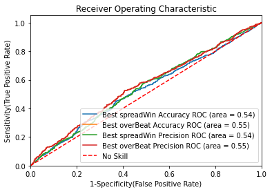

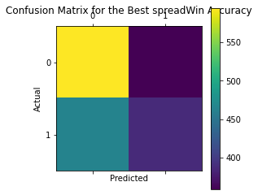

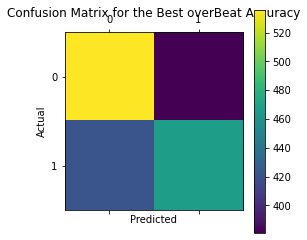

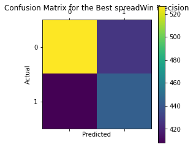

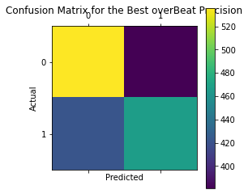

```python
# Based on results above create a dictionary with the best performing models
models = [
{
  'label': 'Best spreadWin Accuracy',
  'target_label' : 'spreadWin',
  'marker': 'o',
  'model': KNeighborsClassifier(n_neighbors=18, weights='distance', metric='chebyshev'),
},
{
  'label': 'Best overBeat Accuracy',
  'target_label' : 'overBeat',
  'marker': 'x',
  'model': KNeighborsClassifier(n_neighbors=40, weights='distance', metric='chebyshev'),
},
{
  'label': 'Best spreadWin Precision',
  'target_label' : 'spreadWin',
  'marker': '<',
  'model': KNeighborsClassifier(n_neighbors=4, weights='distance', metric='manhattan'),
},
{
  'label': 'Best overBeat Precision',
  'target_label' : 'overBeat',
  'marker': '>',
  'model': KNeighborsClassifier(n_neighbors=40, weights='distance', metric='chebyshev'),
}
]

# Create train/test split of the data and targets with a 80/20 split.  Also pass in a random state for result repeatability
data_train, data_test, target_train, target_test = train_test_split(dataReduced, targetVars, test_size=0.2, random_state=123)

# Below for loop iterates through your models list
for m in models:
  model = m['model'] # select the model
  model.fit(data_train, target_train[m['target_label']]) # train the model
  pred = model.predict(data_test) # predict the test data
  # Compute False postive rate, and True positive rate
  fpr, tpr, thresholds = metrics.roc_curve(target_test[m['target_label']], model.predict_proba(data_test)[:,1])
  # Calculate Area under the curve to display on the plot
  auc = metrics.roc_auc_score(target_test[m['target_label']],model.predict(data_test))
  # Now, plot the computed values
  plt.plot(fpr, tpr, label='%s ROC (area = %0.2f)' % (m['label'], auc))
  # Create and store confusion matrix for later plotting
  m['confusion_matrix'] = metrics.confusion_matrix(target_test[m['target_label']], pred)

# Custom settings for the plot
plt.plot([0, 1], [0, 1],'r--',label='No Skill')
plt.xlim([0.0, 1.0])
plt.ylim([0.0, 1.05])
plt.xlabel('1-Specificity(False Positive Rate)')
plt.ylabel('Sensitivity(True Positive Rate)')
plt.title('Receiver Operating Characteristic')
plt.legend(loc="lower right")
plt.show()

# Below for loop iterates through your models list and plots each confusion matrix
for m in models:
  plt.matshow(m['confusion_matrix'])
  plt.colorbar()
  plt.title("Confusion Matrix for the " + m['label'])
  plt.ylabel('Actual')
  plt.xlabel('Predicted')
  plt.show()
```

## Decision Trees

### Predicting OverBeat

Also Decision tree models do not require any scaling of the variables before hand so we did not use the scaled data.

First we will be predicting overBeat, then we will be predicting spreadWin.

```python
#imports
from sklearn.model_selection import train_test_split
from sklearn import tree
from sklearn import *
from sklearn.metrics import classification_report
from sklearn.model_selection import GridSearchCV
import graphviz
from sklearn.tree import export_graphviz
from sklearn.metrics import confusion_matrix
import random
```

```python
#This function makes sure that there are no NA left
def clean_dataset(df):
    assert isinstance(df, pd.DataFrame), "df needs to be a pd.DataFrame"
    df.dropna(inplace=True)
    indices_to_keep = ~df.isin([np.nan, np.inf, -np.inf]).any(1)
    return df[indices_to_keep].astype(np.float64)
```

```python
dataReduced = clean_dataset(dataReduced)
```

```python
targetVars = clean_dataset(targetVars)
```

```python
#The Target Variable is OverBeat
y = targetVars['overBeat']
y = y.to_numpy()
X = dataReduced
```

```python
y
```

```
array([1., 0., 1., ..., 0., 1., 0.])
```

```python
X_train, X_test, y_train, y_test = train_test_split(X, y, test_size=0.2, random_state=33)
X_train.head(5)
```

|  | schedule_playoff | spread_favorite | over_under_line | stadium_neutral | weather_temperature | weather_wind_mph | weather_humidity | homePointsFor | homePointsAgainst | awayPointsFor | awayPointsAgainst | DOME | DOME (Open Roof) | Fog | Rain | Rain \| Fog | Snow | Snow \| Fog | Snow \| Freezing Rain |
| --- | --- | --- | --- | --- | --- | --- | --- | --- | --- | --- | --- | --- | --- | --- | --- | --- | --- | --- | --- |
| 146 | 0.0 | 0.098039 | 0.200000 | 0.0 | 45.0 | 0.175 | 0.65 | 0.248927 | 0.399457 | 0.293991 | 0.437500 | 0.0 | 0.0 | 0.0 | 0.0 | 0.0 | 0.0 | 0.0 | 0.0 |
| 6882 | 0.0 | 0.078431 | 0.457143 | 0.0 | 54.0 | 0.300 | 0.50 | 0.399142 | 0.432065 | 0.474249 | 0.230978 | 0.0 | 0.0 | 0.0 | 0.0 | 0.0 | 0.0 | 0.0 | 0.0 |
| 2569 | 0.0 | 0.078431 | 0.471429 | 0.0 | 54.0 | 0.150 | 0.78 | 0.482833 | 0.467391 | 0.469957 | 0.508152 | 0.0 | 0.0 | 0.0 | 0.0 | 0.0 | 0.0 | 0.0 | 0.0 |
| 7163 | 0.0 | 0.254902 | 0.228571 | 0.0 | 55.0 | 0.075 | 0.90 | 0.379828 | 0.279891 | 0.328326 | 0.652174 | 0.0 | 0.0 | 0.0 | 0.0 | 0.0 | 0.0 | 0.0 | 0.0 |
| 8455 | 0.0 | 0.313725 | 0.528571 | 0.0 | 72.0 | 0.000 | 0.00 | 0.497854 | 0.739130 | 0.341202 | 0.497283 | 1.0 | 0.0 | 0.0 | 0.0 | 0.0 | 0.0 | 0.0 | 0.0 |

```python
X_train.shape[0]
```

```
7221
```

```python
X_train.shape[1]
```

```
19
```

```python
X_test.head()
```

|  | schedule_playoff | spread_favorite | over_under_line | stadium_neutral | weather_temperature | weather_wind_mph | weather_humidity | homePointsFor | homePointsAgainst | awayPointsFor | awayPointsAgainst | DOME | DOME (Open Roof) | Fog | Rain | Rain \| Fog | Snow | Snow \| Fog | Snow \| Freezing Rain |
| --- | --- | --- | --- | --- | --- | --- | --- | --- | --- | --- | --- | --- | --- | --- | --- | --- | --- | --- | --- |
| 179 | 0.0 | 0.117647 | 0.585714 | 0.0 | 50.0 | 0.500 | 0.90 | 0.620172 | 0.744565 | 0.444206 | 0.328804 | 0.0 | 0.0 | 0.0 | 0.0 | 0.0 | 0.0 | 0.0 | 0.0 |
| 2273 | 0.0 | 0.019608 | 0.285714 | 0.0 | 49.0 | 0.225 | 0.59 | 0.315451 | 0.391304 | 0.401288 | 0.538043 | 0.0 | 0.0 | 0.0 | 0.0 | 0.0 | 0.0 | 0.0 | 0.0 |
| 6597 | 0.0 | 0.274510 | 0.300000 | 0.0 | 44.0 | 0.300 | 0.55 | 0.214592 | 0.271739 | 0.527897 | 0.258152 | 0.0 | 0.0 | 0.0 | 0.0 | 0.0 | 0.0 | 0.0 | 0.0 |
| 7877 | 0.0 | 0.490196 | 0.328571 | 0.0 | 59.0 | 0.225 | 0.89 | 0.581545 | 0.377717 | 0.306867 | 0.633152 | 0.0 | 0.0 | 0.0 | 0.0 | 0.0 | 0.0 | 0.0 | 0.0 |
| 6558 | 0.0 | 0.000000 | 0.357143 | 0.0 | 61.0 | 0.425 | 0.62 | 0.278970 | 0.222826 | 0.328326 | 0.407609 | 0.0 | 0.0 | 0.0 | 0.0 | 0.0 | 0.0 | 0.0 | 0.0 |

```python
X_test.shape[0]
```

```
1806
```

We will first make a simple decision tree classifier to predict overBeat. Then we will tune the hyperparameters later.

```python
treeclf = tree.DecisionTreeClassifier()
#Fitting the model on the training data
treeclf = treeclf.fit(X_train, y_train)
#Making predictions with test data
treepreds_test = treeclf.predict(X_test)
```

Now, we will test for overfitting. The model is overfit if the accuracy is very high for the Train data but very low for the test data

```python
#Test data Accuracy
print (treeclf.score(X_test, y_test))
```

```
0.5387596899224806
```

```python
#Train data Accuracy
print (treeclf.score(X_train, y_train))
```

```
1.0
```

```python
#Overall Accuracy
print(classification_report(y_test, treepreds_test))
```

```
              precision    recall  f1-score   support

         0.0       0.55      0.54      0.55       932
         1.0       0.52      0.54      0.53       874

    accuracy                           0.54      1806
   macro avg       0.54      0.54      0.54      1806
weighted avg       0.54      0.54      0.54      1806
```

As we see here the model is extermely overfit. the Test Accuracy is only 53% and the Train accuracy is close to 100% .

Tuning the hyperparameters should help with overfitting. We will be tuning using the following parameters below and using 5-fold cross validation

```python
# Create the parameter grid based on the results of random search
params = {
    'max_depth': [2, 3, 5, 10, 20, 50],
    'max_features': ['auto', 'log2'],
    'min_samples_leaf': [5, 10, 20, 50, 100,150,200],
    'min_samples_split': [2,3,5,10,20,50,100],
    'criterion': ["gini", "entropy"]
}
```

```python
# Instantiate the grid search model
random.seed(123)
grid_search = GridSearchCV(estimator=treeclf,
                           param_grid=params,
                           cv=5, n_jobs=-1, verbose=1, scoring = "accuracy")
```

```python
random.seed(123)
grid_search.fit(X_train, y_train)
```

```
Fitting 5 folds for each of 1176 candidates, totalling 5880 fits
```

```
GridSearchCV(cv=5, estimator=DecisionTreeClassifier(), n_jobs=-1,
             param_grid={'criterion': ['gini', 'entropy'],
                         'max_depth': [2, 3, 5, 10, 20, 50],
                         'max_features': ['auto', 'log2'],
                         'min_samples_leaf': [5, 10, 20, 50, 100, 150, 200],
                         'min_samples_split': [2, 3, 5, 10, 20, 50, 100]},
             scoring='accuracy', verbose=1)
```

```python
grid_search.best_estimator_
```

```
DecisionTreeClassifier(criterion='entropy', max_depth=10, max_features='auto',
                       min_samples_leaf=5, min_samples_split=20)
```

This is the decision tree with the best parameters. Next we will fit the data using these parameters

```python
treeclf = tree.DecisionTreeClassifier(criterion='entropy', max_depth=10, max_features='auto',
                       min_samples_leaf=5, min_samples_split=20)
#Fitting the model on the training data
treeclf = treeclf.fit(X_train, y_train)
#Making predictions with test data
treepreds_test = treeclf.predict(X_test)
```

```python
#Test data Accuracy
overBeat_dt_test_accuracy = treeclf.score(X_test, y_test)
print (treeclf.score(X_test, y_test))
```

```
0.5337763012181617
```

```python
#Train data Accuracy
overBeat_dt_train_accuracy = treeclf.score(X_train, y_train)
print (treeclf.score(X_train, y_train))
```

```
0.6010247888104141
```

```
[[530 402]
 [440 434]]
```

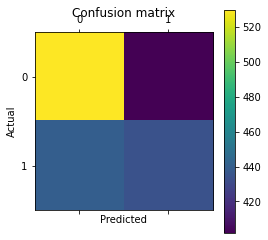

```python
treecm = confusion_matrix(y_test, treepreds_test, labels=[0,1])
print (treecm)

import pylab as plt
%matplotlib inline
plt.matshow(treecm)
plt.title('Confusion matrix')
plt.colorbar()
plt.ylabel('Actual')
plt.xlabel('Predicted')
plt.show()
```

```python
#Overall Accuracy
print(classification_report(y_test, treepreds_test))
```

```
              precision    recall  f1-score   support

         0.0       0.55      0.57      0.56       932
         1.0       0.52      0.50      0.51       874

    accuracy                           0.53      1806
   macro avg       0.53      0.53      0.53      1806
weighted avg       0.53      0.53      0.53      1806
```

Although the test accuracy did not improve as much, the model is no longer overfit because there isn't a large gap between the train data accuracy and the test data.

The Test accuracy is 53% and The Train accuracy is 60%

It should be noted from the confusion matrix and the classification report that the model does have a less that 50% accuracy is predicting the 1 (or True) value.

Next, We will look at the feature Importance and see which variables are the most significant in prediciting overbeat

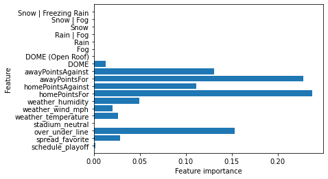

```python
import pylab as plt
%matplotlib inline

def plot_feature_importances(model, n_features, feature_names):
    plt.barh(range(n_features), model.feature_importances_, align='center')
    plt.yticks(np.arange(n_features), feature_names)
    plt.xlabel("Feature importance")
    plt.ylabel("Feature")
    plt.ylim(-1, n_features)

plot_feature_importances(treeclf, len(X.columns), X.columns)
```

As we see here the features with the most amount of importance and the points variables this is followed by over_under_line and weather_huminity.

Now we will visualize the model

```python
export_graphviz(treeclf,out_file='tree.dot', feature_names=X_train.columns,class_names=["No","Yes"], filled=True)

with open("tree.dot") as f:
    dot_graph = f.read()
graphviz.Source(dot_graph)
```

[figure not shown]

Generally speaking, variables at the top of the decision tree do have the most importance

### Predicting spreadWin

Now, similarily to when we predicted overBeat, we will be doing the same for the variable spreadWin. We are using the same predictors as before and doing the same train test split of 80/20

First we will be creating a simple decision tree model and determining if it is overfit and needs the parameters to be tuned.

```python
#The Target Variable is spreadWin
y = targetVars['spreadWin']
y = y.to_numpy()
X = dataReduced
```

```python
X_train, X_test, y_train, y_test = train_test_split(X, y, test_size=0.2, random_state=33)
X_train.head(5)
```

|  | schedule_playoff | spread_favorite | over_under_line | stadium_neutral | weather_temperature | weather_wind_mph | weather_humidity | homePointsFor | homePointsAgainst | awayPointsFor | awayPointsAgainst | DOME | DOME (Open Roof) | Fog | Rain | Rain \| Fog | Snow | Snow \| Fog | Snow \| Freezing Rain |
| --- | --- | --- | --- | --- | --- | --- | --- | --- | --- | --- | --- | --- | --- | --- | --- | --- | --- | --- | --- |
| 146 | 0.0 | 0.098039 | 0.200000 | 0.0 | 45.0 | 0.175 | 0.65 | 0.248927 | 0.399457 | 0.293991 | 0.437500 | 0.0 | 0.0 | 0.0 | 0.0 | 0.0 | 0.0 | 0.0 | 0.0 |
| 6882 | 0.0 | 0.078431 | 0.457143 | 0.0 | 54.0 | 0.300 | 0.50 | 0.399142 | 0.432065 | 0.474249 | 0.230978 | 0.0 | 0.0 | 0.0 | 0.0 | 0.0 | 0.0 | 0.0 | 0.0 |
| 2569 | 0.0 | 0.078431 | 0.471429 | 0.0 | 54.0 | 0.150 | 0.78 | 0.482833 | 0.467391 | 0.469957 | 0.508152 | 0.0 | 0.0 | 0.0 | 0.0 | 0.0 | 0.0 | 0.0 | 0.0 |
| 7163 | 0.0 | 0.254902 | 0.228571 | 0.0 | 55.0 | 0.075 | 0.90 | 0.379828 | 0.279891 | 0.328326 | 0.652174 | 0.0 | 0.0 | 0.0 | 0.0 | 0.0 | 0.0 | 0.0 | 0.0 |
| 8455 | 0.0 | 0.313725 | 0.528571 | 0.0 | 72.0 | 0.000 | 0.00 | 0.497854 | 0.739130 | 0.341202 | 0.497283 | 1.0 | 0.0 | 0.0 | 0.0 | 0.0 | 0.0 | 0.0 | 0.0 |

```python
y_train
```

```
array([0., 0., 1., ..., 1., 0., 1.])
```

```python
treeclf = tree.DecisionTreeClassifier()
#Fitting the model on the training data
treeclf = treeclf.fit(X_train, y_train)
#Making predictions with test data
treepreds_test = treeclf.predict(X_test)
```

```python
#Test data Accuracy
print (treeclf.score(X_test, y_test))
```

```
0.5049833887043189
```

```python
#Train Accuracy
print (treeclf.score(X_train, y_train))
```

```
1.0
```

```python
#Overall Accuracy
print(classification_report(y_test, treepreds_test))
```

```
              precision    recall  f1-score   support

         0.0       0.49      0.54      0.51       874
         1.0       0.52      0.48      0.50       932

    accuracy                           0.50      1806
   macro avg       0.51      0.51      0.50      1806
weighted avg       0.51      0.50      0.50      1806
```

As we see from the results above, The model is very overfit with a train accuracy of 100% but a test accuracy of only 50%.

Next, we will tune the parameters in order to make sure the model is not overfit.

```python
# Create the parameter grid based on the results of random search
params = {
    'max_depth': [2, 3, 5, 10, 20, 50],
    'max_features': ['auto', 'log2'],
    'min_samples_leaf': [5, 10, 20, 50, 100,150,200],
    'min_samples_split': [2,3,5,10,20,50,100],
    'criterion': ["gini", "entropy"]
}
```

```python
# Instantiate the grid search model
random.seed(123)
grid_search = GridSearchCV(estimator=treeclf,
                           param_grid=params,
                           cv=5, n_jobs=-1, verbose=1, scoring = "accuracy")
```

```python
random.seed(123)
grid_search.fit(X_train, y_train)
```

```
Fitting 5 folds for each of 1176 candidates, totalling 5880 fits
```

```
GridSearchCV(cv=5, estimator=DecisionTreeClassifier(), n_jobs=-1,
             param_grid={'criterion': ['gini', 'entropy'],
                         'max_depth': [2, 3, 5, 10, 20, 50],
                         'max_features': ['auto', 'log2'],
                         'min_samples_leaf': [5, 10, 20, 50, 100, 150, 200],
                         'min_samples_split': [2, 3, 5, 10, 20, 50, 100]},
             scoring='accuracy', verbose=1)
```

```python
grid_search.best_estimator_
```

```
DecisionTreeClassifier(criterion='entropy', max_depth=5, max_features='log2',
                       min_samples_leaf=20, min_samples_split=100)
```

The parameters that best fit the model are shown above. Next we will fit a new decision tree model predicting spreadWin and use these parameters instead to make sure there are no problems with overfitting

```python
treeclf = tree.DecisionTreeClassifier(criterion='entropy', max_depth=5, max_features='log2',
                       min_samples_leaf=20, min_samples_split=100)
#Fitting the model on the training data
treeclf = treeclf.fit(X_train, y_train)
#Making predictions with test data
treepreds_test = treeclf.predict(X_test)
```

```python
#Test data Accuracy
spreadwin_dt_test_accuracy = treeclf.score(X_test, y_test)
print (treeclf.score(X_test, y_test))
```

```
0.5249169435215947
```

```python
#Train data Accuracy
spreadwin_dt_train_accuracy = treeclf.score(X_train, y_train)
print (treeclf.score(X_train, y_train))
```

```
0.5949314499376818
```

```python
#Overall Accuracy
print(classification_report(y_test, treepreds_test))
```

```
              precision    recall  f1-score   support

         0.0       0.51      0.59      0.55       874
         1.0       0.55      0.46      0.50       932

    accuracy                           0.52      1806
   macro avg       0.53      0.53      0.52      1806
weighted avg       0.53      0.52      0.52      1806
```

```
[[518 356]
 [502 430]]
```

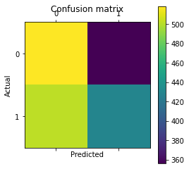

```python
treecm = confusion_matrix(y_test, treepreds_test,labels=[0,1])
print (treecm)

import pylab as plt
%matplotlib inline
plt.matshow(treecm)
plt.title('Confusion matrix')
plt.colorbar()
plt.ylabel('Actual')
plt.xlabel('Predicted')
plt.show()
```

As we see from the confusion matrix above and the results of the train and test model accuracy. We see that although there isn't a problem with overfitting and because the train model accuracy is 59% and the test model accuracy is 52%. There is a problem with predicting the 1 (or True) value

This could be because from the exploratory phase we saw that there wasn't a correlation that was significantly larger than 0 between any of the predictors and our target variable.

Next, we will see which features have the most amount of importance in our model

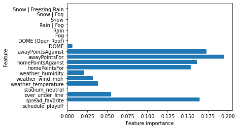

```python
def plot_feature_importances(model, n_features, feature_names):
    plt.barh(range(n_features), model.feature_importances_, align='center')
    plt.yticks(np.arange(n_features), feature_names)
    plt.xlabel("Feature importance")
    plt.ylabel("Feature")
    plt.ylim(-1, n_features)

plot_feature_importances(treeclf, len(X.columns), X.columns)
```

Finally, we will visualize the model.

```python
export_graphviz(treeclf,out_file='tree1.dot', feature_names=X_train.columns,class_names=["No","Yes"], filled=True)

with open("tree.dot") as f:
    dot_graph = f.read()
graphviz.Source(dot_graph)
```

[figure not shown]

### Decision Tree Summary

For the Decision Tree models of overBeat and spreadWin, we found that both of them did share the same predictors that had the most importance in models. These variables were the HomePoints For and aganist and the Away points for and Away points aganist.

However, both of these models had low test accuracys of only slightly above 50%. This shows that these predictors aren't that good at predicting overBeat or spreadWin. This could also be because these predictors aren't that correlated to the target variables.

## Regression

Now we’ll move into regression for predicting the labels for the data. For this task, we will use Logistic regression, as both of our labels are binary and logistic regression is only able to generate predictions for binary variables. The process for building a model and evaluating it will be the same for each label. First, feature selection will be performed in order to have a more understandable model. Feature selection also allows for the compression between the two models to see which features are most important to each label. Logistic regression also helps with determine feature importance, as the coefficients represents the change in odds that the target variable will be 1, so in the case the likelihood that the over will be beaten and the spread will be covered. First, we'll start with building the model and reducing the number of features.

### Imports for Regression

```python
import pandas as pd
import numpy as np
from sklearn import preprocessing
from sklearn.linear_model import LogisticRegression
from sklearn import feature_selection, model_selection, metrics
import matplotlib.pyplot as plt
from tabulate import tabulate
import random
```

### Model Building

```python
random.seed(1223334444)
```

First, we'll create testing and training sets for both labels.

```python
trainOver, testOver, targetTrainOver, targetTestOver = model_selection.train_test_split(dataReduced, targetVars.iloc[:, 0], test_size= .33, random_state=0)
trainSpread, testSpread, targetTrainSpread, targetTestSpread = model_selection.train_test_split(dataReduced, targetVars.iloc[:, 1], test_size= .33, random_state=0)
```

Defining a function that generates an accuracy table that contains the testing and training accuracy of the passed in models.

```python
def generateTable(model, trainSet, testingSet, trainLabels, testingLabels, labelNames):
    accuracies =[]
    for i in range(len(labelNames)):
        cvScore = model_selection.cross_val_score(model[i], trainSet[i], trainLabels[i], cv = 5)
        trainCv = cvScore.mean()
        cvScore = model_selection.cross_val_score(model[i], testingSet[i], testingLabels[i], cv = 5)
        testCv = cvScore.mean()
        accuracies.append([labelNames[i], trainCv, testCv])
    headings = ["Label", "Training Accuracy", "Testing Accuracy"]
    print(tabulate(accuracies, headers=headings))
```

We'll create our two logistic regression models and fit them with the training data.

```python
logRegressOver = LogisticRegression(random_state=0, max_iter=300).fit(trainOver, targetTrainOver)
logRegressSpread = LogisticRegression(random_state=0, max_iter=300).fit(trainSpread, targetTrainSpread)
models = [logRegressOver, logRegressSpread]
```

We'll then generate a baseline accuracy table for our two labels.

```python
generateTable(models, [trainOver, trainSpread], [testOver, testSpread], [targetTrainOver, targetTrainSpread],
                [targetTestOver, targetTestSpread], ["Over", "Spread"])
```

```
Label      Training Accuracy    Testing Accuracy
-------  -------------------  ------------------
Over                0.633765            0.629068
Spread              0.570766            0.560923
```

We'll now define a function to determine the optimal number of features using the cross validation score.

```python
def optimalFeatures(train, target, model, K):
    results = {"topPercentile": 0, "percentiles" : dict()}
    topScore = -1
    for i in range(1, 100, 5):
        fs = feature_selection.SelectPercentile(feature_selection.f_regression, percentile = i)
        trainFs = fs.fit_transform(train, target)
        score = model_selection.cross_val_score(model, trainFs, target, cv = K, scoring="neg_mean_absolute_error")
        score = abs(score).mean()
        results["percentiles"][i] = score
        # Or statement for the first value
        if score < topScore or topScore == -1:
            topScore = score.mean()
            results["topPercentile"] = i

    return results["topPercentile"], results["percentiles"]
```

We'll then determine the optimal number of features for the over label.

```python
logRegress = LogisticRegression(max_iter=300)
optimalPerct, allPercentiles = optimalFeatures(trainOver, targetTrainOver, logRegress, 5)
print("Optimal Percentile  : {}".format(optimalPerct))
```

```
Optimal Percentile  : 76
```

We'll then fit our training and testing sets with the optimal number of features. The warning that appears here is due to our dummy variables being very sparse. Though, the warning is ultimatley harmless and does not affect our results.

```python
fsOver = feature_selection.SelectPercentile(feature_selection.f_regression, percentile= optimalPerct)
trainFsOver = fsOver.fit_transform(trainOver, targetTrainOver)
testFsOver = fsOver.fit_transform(testOver, targetTestOver)
```

```
/usr/local/lib/python3.7/dist-packages/sklearn/feature_selection/_univariate_selection.py:289: RuntimeWarning: invalid value encountered in true_divide
  correlation_coefficient /= X_norms
```

We'll then do the same for the spread label with first determining the optimal number of features.

```python
logRegress = LogisticRegression(max_iter=300)
optimalPerct, allPercentiles = optimalFeatures(trainSpread, targetTrainSpread, logRegress, 5)
print("Optimal Percentile  : {}".format(optimalPerct))
```

```
Optimal Percentile  : 46
```

We'll then transform our training and testing sets for the spread label, reducing them down to the optimal number of features.

```python
fsSpread = feature_selection.SelectPercentile(feature_selection.f_regression, percentile= optimalPerct)
trainFsSpread = fsSpread.fit_transform(trainSpread, targetTrainSpread)
testFsSpread = fsSpread.fit_transform(testSpread, targetTestSpread)
```

We'll then create models using the reduced datasets.

```python
logRegressOver = LogisticRegression(random_state=0, max_iter=300).fit(trainFsOver, targetTrainOver)
logRegressSpread = LogisticRegression(random_state=0, max_iter=300).fit(trainFsSpread, targetTrainSpread)
models = [logRegressOver, logRegressSpread]
```

We'll then check the accuracy to see if there was any significant change after reducing the data space. As shown below, there does not seem to be too much of a difference between using all of the features and using the optimal number of features.

```python
generateTable(models, [trainFsOver, trainFsSpread], [testFsOver, testFsSpread], [targetTrainOver, targetTrainSpread],
                [targetTestOver, targetTestSpread], ["Over", "Spread"])
```

```
Label      Training Accuracy    Testing Accuracy
-------  -------------------  ------------------
Over                0.635087            0.630408
Spread              0.573906            0.553871
```

Next, we'll look at the optimal features for each label. As we can see below, the points for and against for both teams was very important to each label. Both labels seem to be greatly affected by the weather conditions of the stadium, with both having many weather variables along with whether the game was played in a dome or not. The spread label seems to be affected by playoff games, as it includes the playoff game boolean.

```python
for i in range(len(dataReduced.columns.values)):
    if fsOver.get_support()[i]:
        print("{}\t{}".format(dataReduced.columns.values[i], fsOver.scores_[i]))
```

```
schedule_playoff	1.445128737420405
spread_favorite	0.0683101146330259
over_under_line	0.7693044894804623
weather_temperature	2.307788329002281
weather_wind_mph	1.5273896495061865
homePointsFor	43.50023770085029
homePointsAgainst	12.72431424195611
awayPointsFor	27.534189675837347
awayPointsAgainst	21.509478002662146
DOME	0.0743312872321952
DOME (Open Roof)	0.8020176863306678
Fog	1.0747979692215226
Rain | Fog	0.7157226329345385
Snow | Fog	2.0489636069264834
```

```python
for i in range(len(dataReduced.columns.values)):
    if fsSpread.get_support()[i]:
        print("{}\t{}".format(dataReduced.columns.values[i], fsSpread.scores_[i]))
```

```
schedule_playoff	2.9621474763408044
weather_temperature	5.058206090949809
weather_wind_mph	1.4882109678924635
homePointsFor	4.667820453938088
homePointsAgainst	1.5415764018208218
awayPointsFor	3.336554754861021
awayPointsAgainst	14.23991754461037
DOME	3.1726271709905887
Rain	1.990061029224439
```

### Evaluation

To evaluate the models built using the selected features, we will look at accuracy, the confusion matrix and the metrics that come from it (precision, recall, etc.) and ROC curve along with measuring the area under the ROC curve. We’ll also evaluated the features in each model and compare them between models for the two labels.

First, we'll define a function that prints a classification report, a plot of the confusion matrix, and the roc curve for the model.

```python
def genStats(model, testSet, targetTest, label):
    preds = model.predict(testSet)
    print("Classification : ")
    print(metrics.classification_report(targetTest, preds))
    print("Confusion Matrix : ")
    confusionMatrix = metrics.confusion_matrix(targetTest, preds)
    plt.matshow(confusionMatrix)
    plt.colorbar()
    plt.title("Confusion Matrix for the " + label)
    plt.ylabel('Actual')
    plt.xlabel('Predicted')
    plt.show()
    metrics.RocCurveDisplay.from_estimator(model, testSet, targetTest)
```

First we'll run the reporting method for the over label. Starting the classification report, we can see that classifier has very mixed performance. While it has a strong precision value for the zero case, it has value so small it was rounded to zero for the recall. That indicates that while the classifier does not have a lot of false positives for the zero case, it does have a lot of false negatives. The opposite is true for the one case, as it has a weaker precision value, but a strong recall value. The zero cases’ recall value along with the one case’s precision value indicate this classifier is mostly predicting one. This is further shown by the color map on the confusion matrix. The ROC curve is quite poor, as the area under the curve is only slightly above .5 meaning that the model is only slightly better than random chance. That value is so close to .5 that one could probably say that this model is not really any better than random chance overall. This area under the curve value, along with the predictions mostly being one, indicate that this is a quite poor model that does not help show any insights into betting the over.

```
Classification :
              precision    recall  f1-score   support

         0.0       0.83      0.00      0.01      1507
         1.0       0.49      1.00      0.66      1472

    accuracy                           0.50      2979
   macro avg       0.66      0.50      0.33      2979
weighted avg       0.67      0.50      0.33      2979

Confusion Matrix :
```

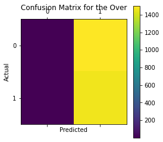

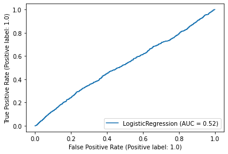

```python
genStats(logRegressOver, testFsOver, targetTestOver, "Over")
```

Now moving on to the spread label and its evaluation report. With the classification report, we can see that this model also has mixed results, similar to the over model. We see a perfect precision value for the zero case, but a zero value for recall. This along with the one case having a perfect recall, likely indicates that the zero case was very infrequently predicted. The confusion matrix with the color map confirms this, as we see that one was mostly predicted. The ROC curve is also quite poor for this model, as the area under the curve is .47. This like the previous model is more or less the same as random chance. Due to the model mostly predicting one and its poor area under the curve, this model is not helpful in finding any insights into betting the spread.

```
Classification :
              precision    recall  f1-score   support

         0.0       1.00      0.00      0.00      1579
         1.0       0.47      1.00      0.64      1400

    accuracy                           0.47      2979
   macro avg       0.74      0.50      0.32      2979
weighted avg       0.75      0.47      0.30      2979

Confusion Matrix :
```

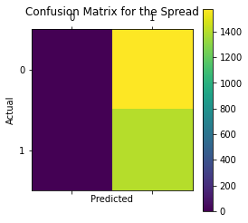

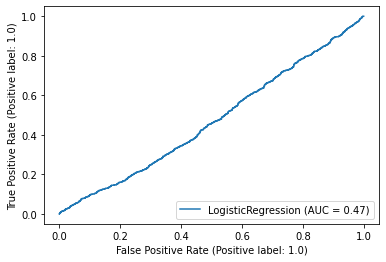

```python
genStats(logRegressSpread, testFsSpread, targetTestSpread, "Spread")
```

### Regression Summary

Overall, we can see that both models perform quite poorly when it comes to predicting the betting outcomes. While both models had a promising accuracy, their confusion matrices and ROC curves show a different result. Both models had very poor area under the curves and were basically just as good as random chance. In looking at the variables included in both models, an avenue of improving the models might be to include more team statistics, as the only team statistics in the data set were included in both models. Though, due to the overall poor performance, these models should likely not be used when deciding whether to place a bet or not and most of these variables are likely not that important in determining what would be a winning bet.

# Conclusion

Most sportsbooks will offer a -110 American odds on spread and over/under bets for NFL games. -110 odds means one would have to bet \$110 to receive a \$100 payout. This equates to an ~91% payout for each successful bet, but a 100% loss for each unsucessful one. This means to be have a positive return, on average, one would have to be better than ~52.4% in prediction accuracy (i.e. better than a coin flip).

The S&P 500, Dow Jones, and NASDAQ all average about 10% annual returns. An NFL season now consists of 17 regular season games. To make the math easier, we won't include the post season. If our betting strategy was to bet on all regular season games each week and compounded the winnings each week (ex. if we come out 5% ahead in Week 1 we bet everything plus that extra 5% in Week 2) we'd have to have a 0.6% return each week to get to a 10% annual return. This was calculated using compount interest equations and compounding interest 17 times. To achieve 0.6% return the our prediction accuracy would need to be ~52.7%. This was calculated by balancing the following equation (Note: we started with \$110 as our initial investment to make the math simpler given the expected -110 odds)

> (Winnings *ProbabilityOfWin) - (Losses* (1 - ProbabilityOfWin)) = 0.006 * InitialInvestment

Plugging in our values we get:

> (\$100 * ProbabilityOfWin) - (\$110 *(1 - ProbabilityOfWin)) = 0.006* \$110

> (\$210 * ProababilityOfWin) - \$110 = \$0.66

> (\$210 * ProbabilityOfWin) = \$110.66

> ProbabilityOfWin = 0.527 = 52.7%

In assessing all of our kNN, decision tree, and regression results there were only slight margins higher than 50% accuracy in predictions. This is seen in the previous section summaries for each supervised learner where classification reports, confusion matrices, and ROC curves are displayed. Though some accuracy and precision values appear higher than the requisite 52.7% value, wtih only 16 games per week for 17 weeks there is a low sample size and thus much opportunity for volatility. This is especially true when comparing 17 game days vs the stock market that trades every business day of the week, minus holidays.

That all said, given our current models and findings, it would lead to opportunity cost going in favor of a major stock index for investing.

## Opportunities for Enhancement

Given what we learned for this project, it is felt there are more opportunities for enhancement that go beyond the scope of our original proposal.

There was discovery that some of the precision and specificity values were higher than the overall accuracy so they could hold some promise in getting further above 52.7% prediction accuracy for single classes.

We, for the most part, confined ourselves to the original predictors of the data set we used from Kaggle. Exploration could be performed to find better predictors with more covariance our labels.

Increasing our breadth of supervised (ex. SVM) and/or unsupervised learners (ex. DBSCAN, HAC) could perhaps lead to better predictive results.

Lastly leveraging ensemble techniques to combine the predictive accuracies, precisions, and specificities of all of our existing models and new ones could increase predictive results as well.

Any combination of any or all of the above could lead to substantially higher than 52.7% prediction accuracy, and thus greater than 10% annual returns.